# Central limit theorem simply explained

NDH802 - Spring 2021

### The research question

Suppose we want to investigate the cheating behaviors among the Swedish students in a school year. We assume 2 outcomes, to cheat or not to cheat. Each student takes ten exams. The probability of cheating is 10% (similarly applicable for all exams, all students). To make it fancier, we write it in statistical language. Let $X$ denote the cheated exams, $X \sim Bin(10, 0.1)$

### Data simulation

Normally, we don’t know the so-called *true* distribution, but for the sake of learning the CLT, let’s pretend we do to simulate data.

Now we have a so-called population data that includes 360,000 rows like these. Each row represents a student with his/her ID and number of exams he/she cheated. For example, student #1 cheated on 1/10 exam(s), student #2 cheated on 0/10 exam, student #3 cheated on 2/10 exam(s), and so on.

```
##    studentID cheat
## 1          1     1
## 2          2     0
## 3          3     2
## 4          4     1
## 5          5     0
## 6          6     1
## 7          7     1
## 8          8     1
## 9          9     0
## 10        10     1
```

Once we have created the data, we pretend (again) it has nothing to do with us. Two activities we often do when we learn statistics are to imagine and to pretend we know or don’t know things, depending on the questions.

Back to our research question. If we had unlimited time and resources, we would investigate each and every student and record his/her cheating behavior. Unfortunately, we don’t. That’s when sampling comes to our rescue.

### Sampling

Let’s imagine we have huge budget. We draw a sample of 100 students to investigate, and record the sample mean of the cheated exams. We call it $\bar{X_i}$. We repeat it 5000 times, i.e, we finally have 5000 values of $\bar{X_i}$. We put them together and call it (vector) $\bar{X}$. The distribution of $\bar{X}$ is plotted in the histogram below (left hand side).

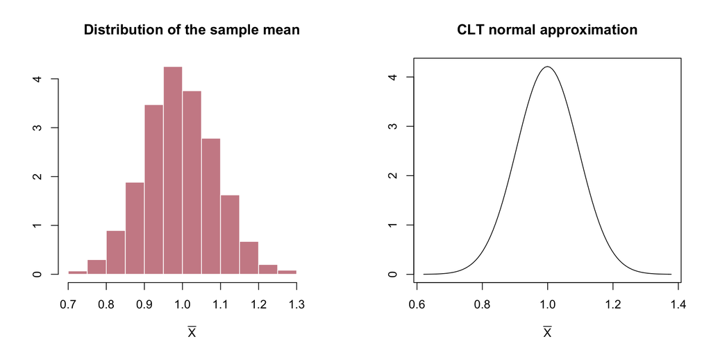

Now, let’s stop imagining. We usually work with tight budget. We are therefore grateful to the statistician who came up with one of the most powerful foundation of statistics. **The Central Limit Theorem suggests that when we have a huge number of observations (the number of realities in our case), these means** follow a normal distribution. Formally, when $n$ is large, $\bar{X_n} \sim N(\mu,\frac{\sigma^2}{n})$. This curve is plotted above (right hand side).

```r
cutpoint = 1
data_prob = sum(sample_mean > cutpoint)/length(sample_mean)
clt_prob = pnorm(cutpoint, mean = mu, sd = sqrt(sigma_squared_clt), lower.tail = F)
data.frame(data_prob, clt_prob)
```

```
##   data_prob  clt_prob
## 1    0.4564 0.4974611
```

Not identical, but pretty close right? We are computing this with sample size of 100. When the sample size gets larger, the results would get closer.

Last time we pose an interesting question, **how large is large and how close is close?** The answer is beautifully captured in the variance of the normal approximation $\frac{\sigma^2}{n}$. Technically, when $n$ tends to $\infty$, the variance tends to 0. In real life, it means when $n$ gets larger and larger, the variance get smaller and smaller, i.e., we are more and more certain about the $\mu$.

### Key takeaways

1. Distribution of the random variable $X$ is **different from** the distribution of the sample mean $\bar{X}$.
2. When the number of observations is large, the sampling distribution of the sample mean $\bar{X}$ converges (approximates) to the normal distribution $N(\mu,\frac{\sigma^2}{n})$, regardless of the distribution of $X$.

For example, the blue bars illustrate the number of cheated exams following binomial distribution, while the pink bars represent the **average** number of cheated exams (the **sample mean**), following normal distribution when the sample size is large.

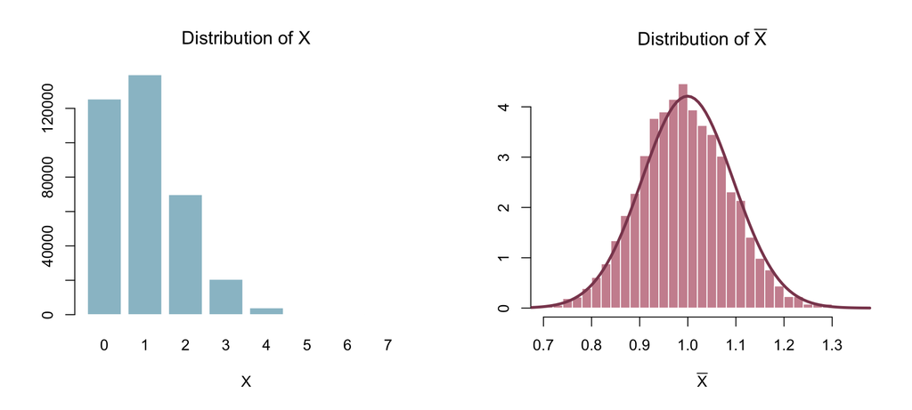

3. In reality, we normally don’t know the population distribution. Thanks to point (ii), we can infer the population mean $\mu$ from the sample mean $\bar{X}$.